# INFER Semiconductor Trade Forecasting

[Ryan Beck](https://twitter.com/ryanbeck111)

Last updated: April 03, 2023

This page contains semiconductor trade data for use in forecasting the following questions on INFER:

- [What will be the value, in dollars, of U.S. exports of semiconductor chips to China in 2022?](https://www.infer-pub.com/questions/130-what-will-be-the-value-in-dollars-of-u-s-exports-of-semiconductor-chips-to-china-in-2022)
- [What will be the value, in dollars, of all Chinese imports of semiconductor manufacturing equipment in 2022?](https://www.infer-pub.com/questions/128-what-will-be-the-value-in-dollars-of-all-chinese-imports-of-semiconductor-manufacturing-equipment-in-2022)
- [What will be the value, in dollars, of all Chinese imports of semiconductor chips in 2022?](https://www.infer-pub.com/questions/129-what-will-be-the-value-in-dollars-of-all-chinese-imports-of-semiconductor-chips-in-2022)
- [What will be the value, in dollars, of U.S. exports of semiconductor manufacturing equipment to China in 2022?](https://www.infer-pub.com/questions/131-what-will-be-the-value-in-dollars-of-u-s-exports-of-semiconductor-manufacturing-equipment-to-china-in-2022)

Data is updated automatically at regular intervals and is sourced from COMTRADE.

**Important Note: The annual data for US exports to China is a summation of monthly data, so data for the current year is to-date and is not complete.**

Click the “Code” buttons to see the R code used on this page. An R Markdown file of this page is [available here](https://github.com/ryooan/ryooan.github.io/tree/master/forecasting) for anyone who wishes to download and run or modify it themselves.

```r
library(jsonlite)
library(tidyverse)
library(lubridate)
library(scales)
library(zoo)
library(tidyr)
library(kableExtra)

#
#
#
#US exports of SME to China
#
#
#

us_sme_china <- read.csv(url("https://comtrade.un.org/api/get?type=C&freq=M&px=HS&ps=all&r=842&p=156&rg=2&cc=8486%2C903082%2C903141%2C854311%2C901041&fmt=csv"))

us_sme_china <- select(us_sme_china,"Period","Trade.Value..US..")

us_sme_china <- cbind("Date" = as.Date(parse_date_time(us_sme_china$Period,"ym")),us_sme_china)

us_sme_china <- us_sme_china %>% group_by(Date) %>% summarise(Value = sum(Trade.Value..US..)) %>% ungroup()

us_sme_china <- transform(us_sme_china,Rolling.Sum = rollapply(Value,12,sum, fill = NA, align = "left"))

us_sme_china <- transform(us_sme_china,Rolling.Average = rollapply(as.numeric(Value),6,mean, fill = NA, align = "right"))

us_sme_china_annual <- us_sme_china

us_sme_china_annual$DateFloor <- floor_date(us_sme_china_annual$Date,"year")

us_sme_china_annual <- us_sme_china_annual %>% group_by(DateFloor) %>% mutate(Annual.Sum = sum(Value)) %>% ungroup()

us_sme_china_annual$Annual.Sum[duplicated(us_sme_china_annual$Annual.Sum)] <- NA

us_sme_china_annual <- select(us_sme_china_annual,"Date","Rolling.Sum","Annual.Sum")

us_sme_china_annual_long <- gather(us_sme_china_annual,Type,Sum,Rolling.Sum,Annual.Sum)

us_sme_china_annual_long <- na.omit(us_sme_china_annual_long)

us_sme_china <- select(us_sme_china,"Date","Value","Rolling.Average")

us_sme_china_long <- gather(us_sme_china,Type,Result,Value,Rolling.Average)

us_sme_china_monthly_plot <- ggplot(us_sme_china_long, aes(Date,Result)) +
  geom_line(size=0.75, aes(color=Type)) +
  labs(x="Month", y="Export Value (Millions of Dollars)", title="US to China Monthly Semiconductor Equipment Exports",color = "Legend") +
  scale_color_hue(labels = c("6 Month Rolling Average", "Monthly Value")) +
  scale_y_continuous(labels = label_dollar(scale = 1e-6), limits = c(0, NA), expand = expansion(mult = c(0, 0.2))) +
  scale_x_date(breaks="1 year",labels = date_format("%b/%y")) +
  theme_classic() +
  theme(axis.text.x = element_text(angle = 90, vjust = 0.5, hjust=1)) +
  theme(panel.grid.major = element_line(colour = "grey"), panel.grid.minor = element_line(colour = "gray90")) +
  theme(legend.position = "top") +
  theme(legend.title = element_blank())

#Expand limits: https://stackoverflow.com/questions/27028825/ggplot2-force-y-axis-to-start-at-origin-and-float-y-axis-upper-limit/59056123#59056123

us_sme_china_annual_plot <- ggplot(us_sme_china_annual_long, aes(Date,Sum)) +
  geom_line(size=0.75, aes(color=Type)) +
  geom_point(data = us_sme_china_annual_long[us_sme_china_annual_long$Type == "Annual.Sum",], color = "red", size=2) +
  labs(x="Year", y="Export Value (Billions of Dollars)", title="US to China Annual Semiconductor Equipment Exports", color = "Legend") +
  scale_color_hue(labels = c("Annual", "12-Month Rolling Sum")) +
  scale_y_continuous(labels = label_dollar(scale = 1e-9), limits = c(0, NA), expand = expansion(mult = c(0, 0.2))) +
  scale_x_date(breaks="1 year",labels = date_format("%Y")) +
  expand_limits(y = c(0,NA)) +
  theme_classic() +
  theme(axis.text.x = element_text(angle = 90, vjust = 0.5, hjust=1)) +
  theme(panel.grid.major = element_line(colour = "grey"), panel.grid.minor = element_line(colour = "gray90")) +
  theme(legend.position = "top") +
  theme(legend.title = element_blank())

us_sme_china_combined <- us_sme_china

us_sme_china_combined <- transform(us_sme_china_combined,Rolling.Sum = rollapply(Value,12,sum, fill = NA, align = "right"))

us_sme_china_combined$DateCeiling <- floor_date(rollback(ceiling_date(us_sme_china_combined$Date,"year")),"month")

us_sme_china_combined <- us_sme_china_combined %>% group_by(DateCeiling) %>% mutate(Annual.Sum = sum(Value)) %>% ungroup()

us_sme_china_combined <- us_sme_china_combined[,c("Date","Value","Rolling.Average","Rolling.Sum","Annual.Sum")]

us_sme_china_combined[,2:5] <- us_sme_china_combined[,2:5]/1000000


us_sme_china_combined <- us_sme_china_combined %>% arrange(desc(Date))

#number formatting discussion: https://stackoverflow.com/questions/3443687/formatting-decimal-places-in-r
us_sme_china_combined_formatted <- us_sme_china_combined %>% mutate_if(is.numeric,round,digits=0) %>% mutate_if(is.numeric,format,nsmall=0,big.mark=",")

us_sme_china_monthly_table <- kbl(us_sme_china_combined_formatted,col.names = c("Date","Monthly Export","6 Month Rolling Average","Rolling Annual Total","Total by Year")) %>%
  add_header_above(c(" " = 1,"Monthly Values (Millions of $)" = 2,"Annual Values (Millions of $)" = 2)) %>%
  kable_minimal(full_width = F) %>%
  column_spec(1,width_min = "6em") %>%
  scroll_box(width = "100%", height = "500px")
#
#
#
#US exports of chips to China
#
#
#
us_chips_china <- read.csv(url("https://comtrade.un.org/api/get?type=C&freq=M&px=HS&ps=all&r=842&p=156&rg=2&cc=8542&fmt=csv"))

us_chips_china <- select(us_chips_china,"Period","Trade.Value..US..")

us_chips_china <- cbind("Date" = as.Date(parse_date_time(us_chips_china$Period,"ym")),us_chips_china)

us_chips_china <- us_chips_china %>% group_by(Date) %>% summarise(Value = sum(Trade.Value..US..)) %>% ungroup()

us_chips_china <- transform(us_chips_china,Rolling.Sum = rollapply(Value,12,sum, fill = NA, align = "left"))

us_chips_china <- transform(us_chips_china,Rolling.Average = rollapply(as.numeric(Value),6,mean, fill = NA, align = "right"))

us_chips_china_annual <- us_chips_china

us_chips_china_annual$DateFloor <- floor_date(us_chips_china_annual$Date,"year")

us_chips_china_annual <- us_chips_china_annual %>% group_by(DateFloor) %>% mutate(Annual.Sum = sum(Value)) %>% ungroup()

us_chips_china_annual$Annual.Sum[duplicated(us_chips_china_annual$Annual.Sum)] <- NA

us_chips_china_annual <- select(us_chips_china_annual,"Date","Rolling.Sum","Annual.Sum")

us_chips_china_annual_long <- gather(us_chips_china_annual,Type,Sum,Rolling.Sum,Annual.Sum)

us_chips_china_annual_long <- na.omit(us_chips_china_annual_long)

us_chips_china <- select(us_chips_china,"Date","Value","Rolling.Average")
```

```r
us_chips_china_long <- gather(us_chips_china,Type,Result,Value,Rolling.Average)

us_chips_china_monthly_plot <- ggplot(us_chips_china_long, aes(Date,Result)) +
  geom_line(size=0.75, aes(color=Type)) +
  labs(x="Month", y="Export Value (Millions of Dollars)", title="US to China Monthly Semiconductor Chips Exports",color = "Legend") +
  scale_color_hue(labels = c("6 Month Rolling Average", "Monthly Value")) +
  scale_y_continuous(labels = label_dollar(scale = 1e-6), limits = c(0, NA), expand = expansion(mult = c(0, 0.2))) +
  scale_x_date(breaks="1 year",labels = date_format("%b/%y")) +
  theme_classic() +
  theme(axis.text.x = element_text(angle = 90, vjust = 0.5, hjust=1)) +
  theme(panel.grid.major = element_line(colour = "grey"), panel.grid.minor = element_line(colour = "gray90")) +
  theme(legend.position = "top") +
  theme(legend.title = element_blank())

#Expand limits: https://stackoverflow.com/questions/27028825/ggplot2-force-y-axis-to-start-at-origin-and-float-y-axis-upper-limit/59056123#59056123

us_chips_china_annual_plot <- ggplot(us_chips_china_annual_long, aes(Date,Sum)) +
  geom_line(size=0.75, aes(color=Type)) +
  geom_point(data = us_chips_china_annual_long[us_chips_china_annual_long$Type == "Annual.Sum",], color = "red", size=2) +
  labs(x="Year", y="Export Value (Billions of Dollars)", title="US to China Annual Semiconductor Chips Exports", color = "Legend") +
  scale_color_hue(labels = c("Annual", "12-Month Rolling Sum")) +
  scale_y_continuous(labels = label_dollar(scale = 1e-9), limits = c(0, NA), expand = expansion(mult = c(0, 0.2))) +
  scale_x_date(breaks="1 year",labels = date_format("%Y")) +
  expand_limits(y = c(0,NA)) +
  theme_classic() +
  theme(axis.text.x = element_text(angle = 90, vjust = 0.5, hjust=1)) +
  theme(panel.grid.major = element_line(colour = "grey"), panel.grid.minor = element_line(colour = "gray90")) +
  theme(legend.position = "top") +
  theme(legend.title = element_blank())

us_chips_china_combined <- us_chips_china

us_chips_china_combined <- transform(us_chips_china_combined,Rolling.Sum = rollapply(Value,12,sum, fill = NA, align = "right"))

us_chips_china_combined$DateCeiling <- floor_date(rollback(ceiling_date(us_chips_china_combined$Date,"year")),"month")

us_chips_china_combined <- us_chips_china_combined %>% group_by(DateCeiling) %>% mutate(Annual.Sum = sum(Value)) %>% ungroup()

us_chips_china_combined <- us_chips_china_combined[,c("Date","Value","Rolling.Average","Rolling.Sum","Annual.Sum")]

us_chips_china_combined[,2:5] <- us_chips_china_combined[,2:5]/1000000


us_chips_china_combined <- us_chips_china_combined %>% arrange(desc(Date))
#number formatting discussion: https://stackoverflow.com/questions/3443687/formatting-decimal-places-in-r
us_chips_china_combined_formatted <- us_chips_china_combined %>% mutate_if(is.numeric,round,digits=0) %>% mutate_if(is.numeric,format,nsmall=0,big.mark=",")

us_chips_china_monthly_table <- kbl(us_chips_china_combined_formatted,col.names = c("Date","Monthly Export","6 Month Rolling Average","Rolling Annual Total","Total by Year")) %>%
  add_header_above(c(" " = 1,"Monthly Values (Millions of $)" = 2,"Annual Values (Millions of $)" = 2)) %>%
  kable_minimal(full_width = F) %>%
  column_spec(1,width_min = "6em") %>%
  scroll_box(width = "100%", height = "500px")
#
#
#
#china chips imports total
#
#
#
china_chip_imports <- read.csv(url("https://comtrade.un.org/api/get?max=100000&type=C&freq=A&px=HS&ps=all&r=156&p=0&rg=1&cc=8542&fmt=csv"))

china_chip_imports <- select(china_chip_imports,"Period","Trade.Value..US..")

china_chip_imports <- cbind("Date" = as.Date(parse_date_time(china_chip_imports$Period,"y")),china_chip_imports)

china_chip_imports <- china_chip_imports %>% group_by(Date) %>% summarise(Value = sum(Trade.Value..US..)) %>% ungroup()

china_chip_imports_annual_plot <- ggplot(china_chip_imports, aes(Date,Value)) +
  geom_line(size=0.75, color = "red") +
  geom_point(color = "red", size=2) +
  labs(x="Year", y="Import Value (Billions of Dollars)", title="China Annual Semiconductor Chip Imports") +
  scale_y_continuous(labels = label_dollar(scale = 1e-9), limits = c(0, NA), expand = expansion(mult = c(0, 0.2))) +
  scale_x_date(breaks="1 year",labels = date_format("%Y")) +
  expand_limits(y = c(0,NA)) +
  theme_classic() +
  theme(axis.text.x = element_text(angle = 90, vjust = 0.5, hjust=1)) +
  theme(panel.grid.major = element_line(colour = "grey")) +
  theme(legend.position = "top") +
  theme(legend.title = element_blank())

china_chip_imports_formatted <- china_chip_imports

china_chip_imports_formatted$Date <- format(as.Date(china_chip_imports_formatted$Date),"%Y")
china_chip_imports_formatted[,2] <- china_chip_imports_formatted[,2]/1000000

china_chip_imports_formatted <- china_chip_imports_formatted %>% arrange(desc(Date))

#number formatting discussion: https://stackoverflow.com/questions/3443687/formatting-decimal-places-in-r
china_chip_imports_formatted <- china_chip_imports_formatted %>% mutate_if(is.numeric,round,digits=0) %>% mutate_if(is.numeric,format,nsmall=0,big.mark=",")

china_chip_imports_table <- kbl(china_chip_imports_formatted,col.names = c("Date","Semiconductor Imports (Millions of $)")) %>%
  kable_minimal(full_width = F) %>%
  column_spec(1,width_min = "6em") %>%
  scroll_box(width = "100%", height = "500px")
#
#
#
#china sme imports total
#
#
#

china_sme_imports <- read.csv(url("https://comtrade.un.org/api/get?max=100000&type=C&freq=A&px=HS&ps=all&r=156&p=0&rg=1&cc=8486%2C903082%2C903141%2C854311%2C901041&fmt=csv"))

china_sme_imports <- select(china_sme_imports,"Period","Trade.Value..US..")

china_sme_imports <- cbind("Date" = as.Date(parse_date_time(china_sme_imports$Period,"y")),china_sme_imports)

china_sme_imports <- china_sme_imports %>% group_by(Date) %>% summarise(Value = sum(Trade.Value..US..)) %>% ungroup()

china_sme_imports_annual_plot <- ggplot(china_sme_imports, aes(Date,Value)) +
  geom_line(size=0.75, color = "red") +
  geom_point(color = "red", size=2) +
  labs(x="Year", y="Import Value (Billions of Dollars)", title="China Annual Semiconductor Manufacturing Equipment Imports") +
  scale_y_continuous(labels = label_dollar(scale = 1e-9), limits = c(0, NA), expand = expansion(mult = c(0, 0.2))) +
  scale_x_date(breaks="1 year",labels = date_format("%Y")) +
  expand_limits(y = c(0,NA)) +
  theme_classic() +
  theme(axis.text.x = element_text(angle = 90, vjust = 0.5, hjust=1)) +
  theme(panel.grid.major = element_line(colour = "grey")) +
  theme(legend.position = "top") +
  theme(legend.title = element_blank())
```

```r
china_sme_imports_formatted <- china_sme_imports

china_sme_imports_formatted$Date <- format(as.Date(china_sme_imports_formatted$Date),"%Y")
china_sme_imports_formatted[,2] <- china_sme_imports_formatted[,2]/1000000

china_sme_imports_formatted <- china_sme_imports_formatted %>% arrange(desc(Date))

#number formatting discussion: https://stackoverflow.com/questions/3443687/formatting-decimal-places-in-r
china_sme_imports_formatted <- china_sme_imports_formatted %>% mutate_if(is.numeric,round,digits=0) %>% mutate_if(is.numeric,format,nsmall=0,big.mark=",")

china_sme_imports_table <- kbl(china_sme_imports_formatted,col.names = c("Date","Semiconductor Equipment Imports (Millions of $)")) %>%
  kable_minimal(full_width = F) %>%
  column_spec(1,width_min = "6em") %>%
  scroll_box(width = "100%", height = "500px")
```

## US Semiconductor Manufacturing Equipment Exports to China

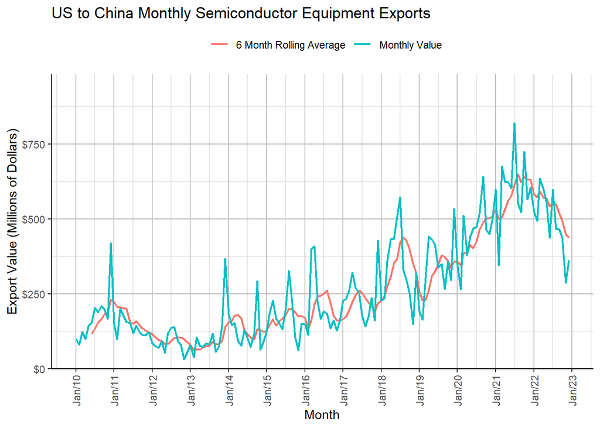

```r
us_sme_china_monthly_plot
```

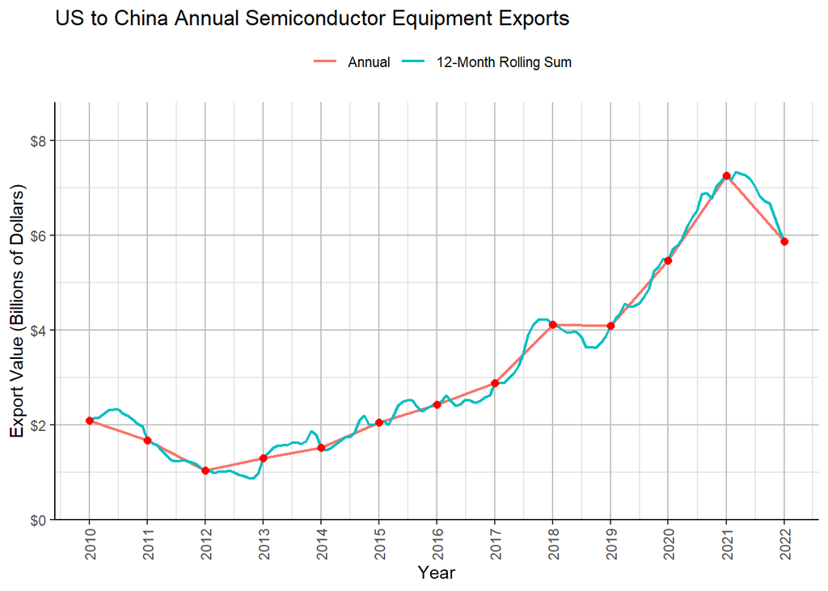

```r
us_sme_china_annual_plot
```

```r
us_sme_china_monthly_table
```

| Date | Monthly Values (Millions of $) Monthly Export | Monthly Values (Millions of $) 6 Month Rolling Average | Annual Values (Millions of $) Rolling Annual Total | Annual Values (Millions of $) Total by Year |
| --- | --- | --- | --- | --- |
| 2022-12-01 | 364 | 437 | 5,866 | 5,866 |
| 2022-11-01 | 288 | 449 | 6,107 | 5,866 |
| 2022-10-01 | 439 | 494 | 6,385 | 5,866 |
| 2022-09-01 | 466 | 520 | 6,670 | 5,866 |
| 2022-08-01 | 467 | 549 | 6,727 | 5,866 |
| 2022-07-01 | 598 | 553 | 6,811 | 5,866 |
| 2022-06-01 | 438 | 541 | 7,032 | 5,866 |
| 2022-05-01 | 554 | 569 | 7,197 | 5,866 |
| 2022-04-01 | 600 | 570 | 7,266 | 5,866 |
| 2022-03-01 | 635 | 591 | 7,290 | 5,866 |
| 2022-02-01 | 494 | 573 | 7,330 | 5,866 |
| 2022-01-01 | 524 | 582 | 7,181 | 5,866 |
| 2021-12-01 | 605 | 631 | 7,254 | 7,254 |
| 2021-11-01 | 565 | 631 | 7,151 | 7,254 |
| 2021-10-01 | 725 | 641 | 7,036 | 7,254 |
| 2021-09-01 | 522 | 624 | 6,776 | 7,254 |
| 2021-08-01 | 552 | 649 | 6,895 | 7,254 |
| 2021-07-01 | 819 | 615 | 6,862 | 7,254 |
| 2021-06-01 | 603 | 578 | 6,517 | 7,254 |
| 2021-05-01 | 623 | 561 | 6,383 | 7,254 |
| 2021-04-01 | 624 | 532 | 6,202 | 7,254 |
| 2021-03-01 | 675 | 506 | 5,957 | 7,254 |
| 2021-02-01 | 345 | 500 | 5,794 | 7,254 |
| 2021-01-01 | 597 | 529 | 5,714 | 7,254 |
| 2020-12-01 | 502 | 508 | 5,466 | 5,466 |
| 2020-11-01 | 450 | 503 | 5,499 | 5,466 |
| 2020-10-01 | 465 | 501 | 5,346 | 5,466 |
| 2020-09-01 | 641 | 487 | 5,239 | 5,466 |
| 2020-08-01 | 519 | 466 | 4,863 | 5,466 |
| 2020-07-01 | 473 | 423 | 4,695 | 5,466 |

[output cut: 126 more lines]

## US Semiconductor Chips Exports to China

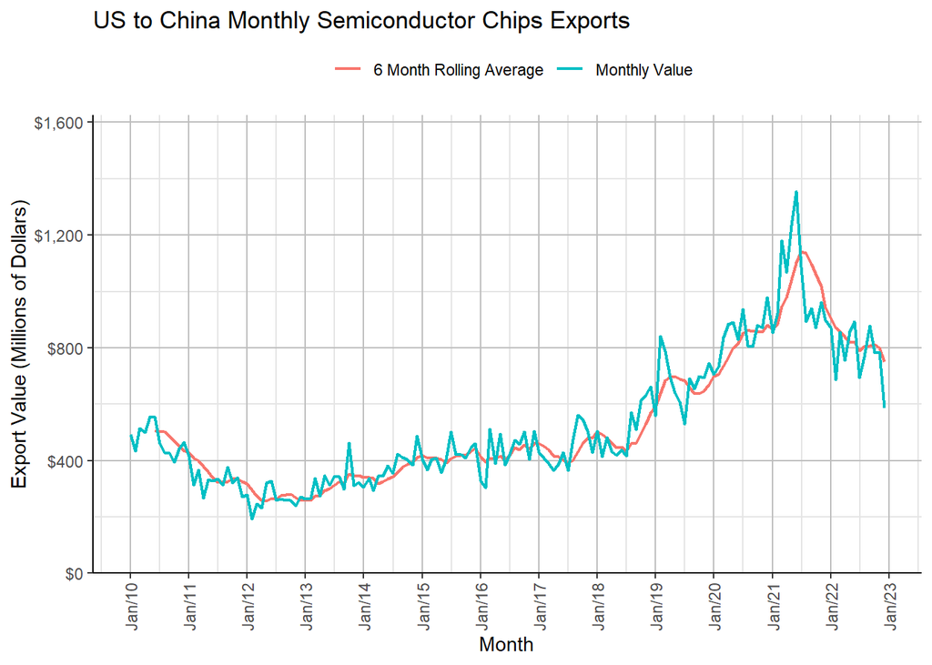

```r
us_chips_china_monthly_plot
```

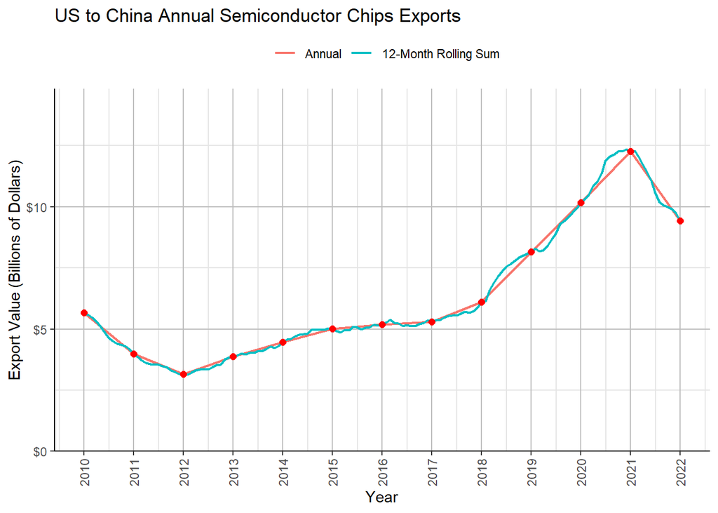

```r
us_chips_china_annual_plot
```

```r
us_chips_china_monthly_table
```

| Date | Monthly Values (Millions of $) Monthly Export | Monthly Values (Millions of $) 6 Month Rolling Average | Annual Values (Millions of $) Rolling Annual Total | Annual Values (Millions of $) Total by Year |
| --- | --- | --- | --- | --- |
| 2022-12-01 | 586 | 749 | 9,418 | 9,418 |
| 2022-11-01 | 784 | 801 | 9,729 | 9,418 |
| 2022-10-01 | 784 | 813 | 9,906 | 9,418 |
| 2022-09-01 | 879 | 808 | 9,993 | 9,418 |
| 2022-08-01 | 768 | 804 | 10,055 | 9,418 |
| 2022-07-01 | 695 | 791 | 10,179 | 9,418 |
| 2022-06-01 | 894 | 820 | 10,573 | 9,418 |
| 2022-05-01 | 857 | 821 | 11,033 | 9,418 |
| 2022-04-01 | 754 | 838 | 11,410 | 9,418 |
| 2022-03-01 | 857 | 858 | 11,723 | 9,418 |
| 2022-02-01 | 687 | 871 | 12,047 | 9,418 |
| 2022-01-01 | 871 | 906 | 12,282 | 9,418 |
| 2021-12-01 | 897 | 942 | 12,265 | 12,265 |
| 2021-11-01 | 961 | 1,018 | 12,346 | 12,265 |
| 2021-10-01 | 871 | 1,063 | 12,256 | 12,265 |
| 2021-09-01 | 941 | 1,096 | 12,266 | 12,265 |
| 2021-08-01 | 893 | 1,136 | 12,131 | 12,265 |
| 2021-07-01 | 1,088 | 1,141 | 12,046 | 12,265 |
| 2021-06-01 | 1,354 | 1,102 | 11,895 | 12,265 |
| 2021-05-01 | 1,234 | 1,040 | 11,371 | 12,265 |
| 2021-04-01 | 1,068 | 979 | 11,029 | 12,265 |
| 2021-03-01 | 1,181 | 948 | 10,845 | 12,265 |
| 2021-02-01 | 923 | 886 | 10,500 | 12,265 |
| 2021-01-01 | 855 | 866 | 10,311 | 12,265 |
| 2020-12-01 | 978 | 880 | 10,162 | 10,162 |
| 2020-11-01 | 872 | 856 | 9,929 | 10,162 |
| 2020-10-01 | 881 | 859 | 9,752 | 10,162 |
| 2020-09-01 | 806 | 859 | 9,571 | 10,162 |
| 2020-08-01 | 808 | 864 | 9,419 | 10,162 |
| 2020-07-01 | 937 | 852 | 9,302 | 10,162 |

[output cut: 126 more lines]

## China Semiconductor Manufacturing Equipment Imports

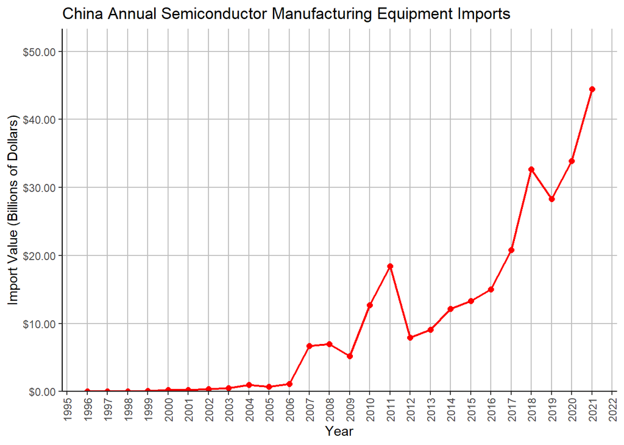

```r
china_sme_imports_annual_plot
```

```r
china_sme_imports_table
```

| Date | Semiconductor Equipment Imports (Millions of $) |
| --- | --- |
| 2021 | 44,447 |
| 2020 | 33,865 |
| 2019 | 28,317 |
| 2018 | 32,663 |
| 2017 | 20,821 |
| 2016 | 15,047 |
| 2015 | 13,284 |
| 2014 | 12,151 |
| 2013 | 9,122 |
| 2012 | 7,964 |
| 2011 | 18,436 |
| 2010 | 12,729 |
| 2009 | 5,229 |
| 2008 | 6,972 |
| 2007 | 6,723 |
| 2006 | 1,126 |
| 2005 | 729 |
| 2004 | 978 |
| 2003 | 479 |
| 2002 | 367 |
| 2001 | 253 |
| 2000 | 228 |
| 1999 | 89 |
| 1998 | 46 |
| 1997 | 35 |
| 1996 | 22 |

## China Semiconductor Chips Imports

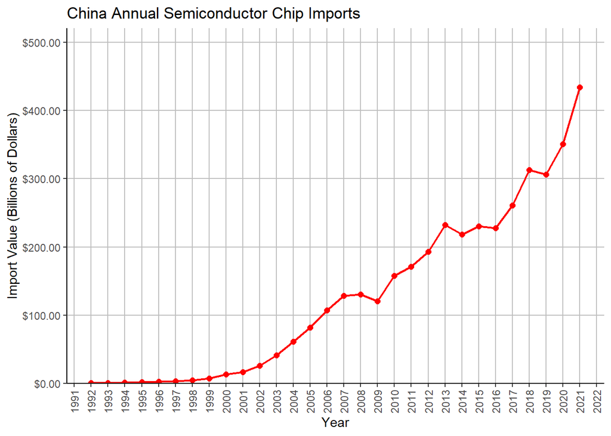

```r
china_chip_imports_annual_plot
```

```r
china_chip_imports_table
```

| Date | Semiconductor Imports (Millions of $) |
| --- | --- |
| 2021 | 433,727 |
| 2020 | 350,770 |
| 2019 | 306,397 |
| 2018 | 312,952 |
| 2017 | 261,161 |
| 2016 | 227,617 |
| 2015 | 230,657 |
| 2014 | 218,520 |
| 2013 | 232,078 |
| 2012 | 192,967 |
| 2011 | 171,142 |
| 2010 | 158,010 |
| 2009 | 120,751 |
| 2008 | 130,583 |
| 2007 | 128,664 |
| 2006 | 107,152 |
| 2005 | 82,202 |
| 2004 | 61,707 |
| 2003 | 41,834 |
| 2002 | 26,374 |
| 2001 | 16,998 |
| 2000 | 13,800 |
| 1999 | 7,924 |
| 1998 | 4,879 |
| 1997 | 3,642 |
| 1996 | 2,725 |
| 1995 | 2,366 |
| 1994 | 1,634 |
| 1993 | 1,165 |
| 1992 | 863 |